# Spotify Exploration

Julia Koh, Dana Korssjoen, Heeju Son, and Allison Wick

## Introduction

Our problem domain analyzes audio features and music genres and answers the questions:

- How do audio features vary across genres?
- How do audio features vary across popular songs in different countries?

## Summary

The dataset has 200907 observations and 18 variables. These variables are the columns of the datasets, and the column names are genre, artist_name, track_name, track_id, popularity, acousticness, danceability, duration_ms, energy, instrumentalness, key, liveness, loudness, mode, speechiness, tempo, time_signature, valence. This particlar project is interested in understanding the variance of different audio features across genres. Therefore, the different genres observed in the dataset are Opera, Alternative, Blues, Dance, Pop, Electronic, R&B, Children’s Music, Folk, Anime, Rap, Classical, Reggae, Hip-Hop, Country, Reggaeton, Ska, Indie, Rock, Soul, Jazz, World. Lastly, it is important to note that while the number of observations for the genres are similar, they are not equal. This is expressed in the table below.

| Var1 | Freq |
| --- | --- |
| Alternative | 9353 |
| Anime | 9353 |
| Blues | 9353 |
| Children’s Music | 9353 |
| Classical | 9256 |
| Country | 8664 |
| Dance | 8701 |
| Electronic | 9377 |
| Folk | 9299 |
| Hip-Hop | 9295 |
| Indie | 9543 |
| Jazz | 9441 |
| Opera | 8280 |
| Pop | 9386 |
| R&B | 8992 |
| Rap | 9232 |
| Reggae | 8771 |
| Reggaeton | 8927 |
| Rock | 9272 |
| Ska | 8874 |
| Soul | 9089 |
| World | 9096 |

## Table

| Genre | Average Danceability | Average Energy | Average Valence | Average Acousticness | Average Tempo | Popularity Rating |
| --- | --- | --- | --- | --- | --- | --- |
| Pop | 0.64 | 0.64 | 0.48 | 0.22 | 121.18 | 67 |
| Rap | 0.70 | 0.65 | 0.46 | 0.17 | 121.10 | 61 |
| Rock | 0.54 | 0.68 | 0.52 | 0.20 | 122.63 | 60 |
| Hip-Hop | 0.72 | 0.64 | 0.47 | 0.18 | 120.79 | 58 |
| Dance | 0.64 | 0.70 | 0.52 | 0.15 | 120.80 | 57 |
| Alternative | 0.54 | 0.71 | 0.45 | 0.16 | 121.93 | 55 |
| Anime | 0.54 | 0.71 | 0.45 | 0.16 | 121.93 | 55 |
| Blues | 0.54 | 0.71 | 0.45 | 0.16 | 121.93 | 55 |
| Children’s Music | 0.54 | 0.71 | 0.45 | 0.16 | 121.93 | 55 |
| Indie | 0.57 | 0.58 | 0.43 | 0.33 | 119.29 | 55 |
| R&B | 0.64 | 0.56 | 0.45 | 0.29 | 116.37 | 52 |
| Folk | 0.53 | 0.49 | 0.44 | 0.46 | 118.75 | 50 |
| Soul | 0.62 | 0.53 | 0.48 | 0.36 | 115.32 | 47 |
| Country | 0.58 | 0.64 | 0.54 | 0.27 | 123.41 | 46 |
| Jazz | 0.59 | 0.47 | 0.51 | 0.50 | 111.78 | 41 |
| Electronic | 0.62 | 0.74 | 0.39 | 0.12 | 125.85 | 38 |
| Reggaeton | 0.73 | 0.75 | 0.66 | 0.22 | 120.99 | 38 |
| Reggae | 0.70 | 0.64 | 0.68 | 0.19 | 118.16 | 36 |
| World | 0.44 | 0.51 | 0.30 | 0.39 | 119.82 | 36 |
| Classical | 0.31 | 0.18 | 0.21 | 0.87 | 104.34 | 29 |
| Ska | 0.53 | 0.82 | 0.65 | 0.10 | 129.43 | 29 |
| Opera | 0.29 | 0.17 | 0.19 | 0.95 | 101.80 | 13 |

## Charts

### Bar Chart

Please note: Valence as described by the Spotify API is the postiveness of the song (0 - extremely negative; 1 - highly positive).

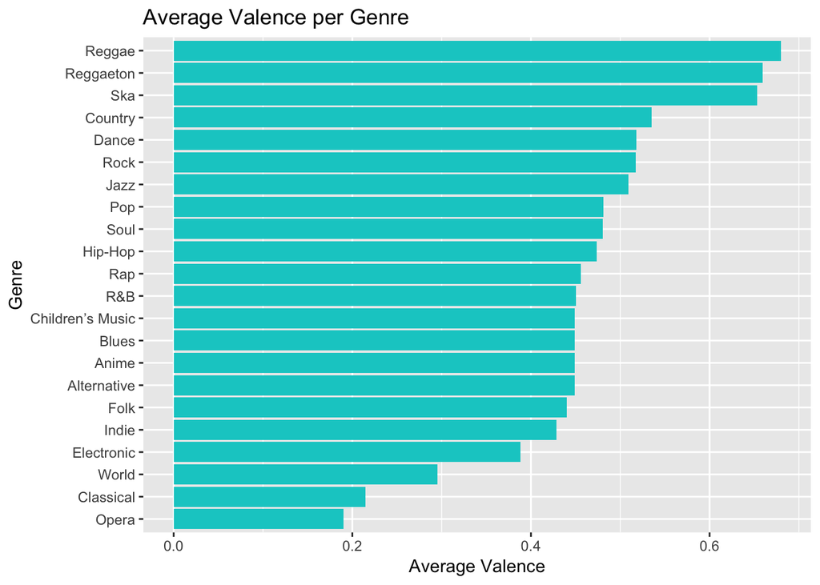

The information from the chart reveals that music categorized as “regge” has the highest valence and “opera” music has the lowest valence. As we look at the ordering of the valence scores, the placement of some genres is not completely surprising as our team can imagine the cultural characteristics associated with each genre. For example, operatic themes trend towards dishonor and suicide, unrequited love, death and pain, all accounting for the genre’s low valence score. On the other hand, the chart reveals surprising findings such as how reggae has the highest valence score. This is strange since reggae music boasts musical themes such as social criticism and diaspora feelings, which are arguably negative topics. However, this leads us into further investigation, as the Spotify API does not state how valence is measured it is possible that factors other than lyrics contribute to the score. Therefore, we hope to examine how other features like speechiness, tempo, danceability, etc. contribute to valence, as well as examine how audio features vary across genres.

### Histogram

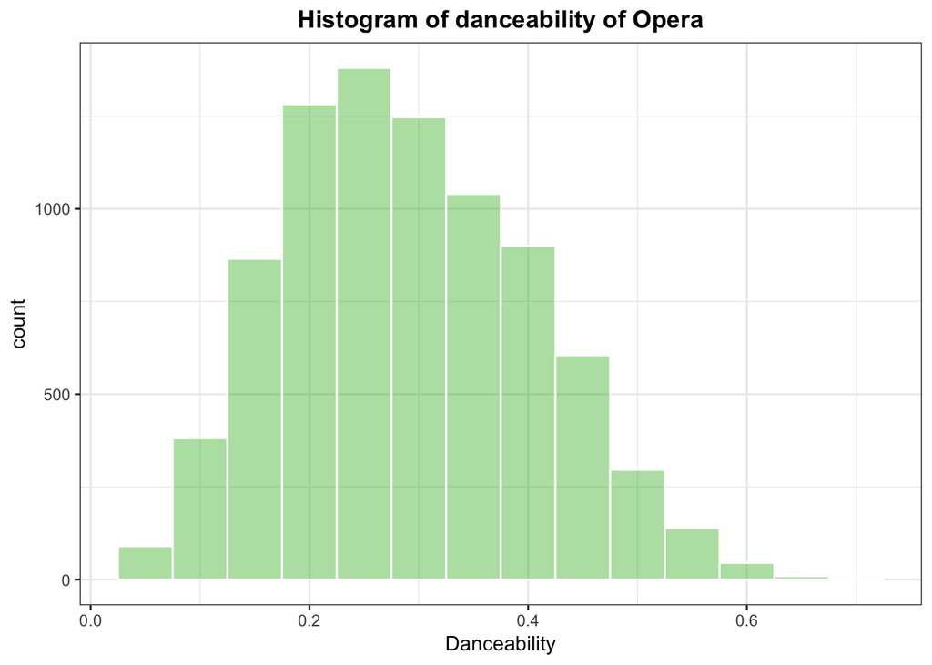